# Statistics for e-Science

December 19, 2016

## Exercise 4.4

**The likelihood ratio test and the two-sample t-test**

Checking the potential of the likelihood ratio and the two-sample t tests.

- Simulate data coming from similar, but *not identical* normal distributions
- Run tests to evalute the significance of the difference of means
- Conclude whether distributions can be approximated or not and tests yield

## 4.4.1 - Simulate data

Assume:

\(X \sim N(\mu = 2, \sigma = 4)\)

\(Y \sim N(\mu = 2.5, \sigma = 4)\)

```r
x <- rnorm(20, 2, 4)
y <- rnorm(40, 2.5, 4)
xy <- c(x, y)
```

- x consists of a sample of X with size 20
- y consists of a sample of Y with size 40
- xy results from merging both samples into a single one

## Theory and practice

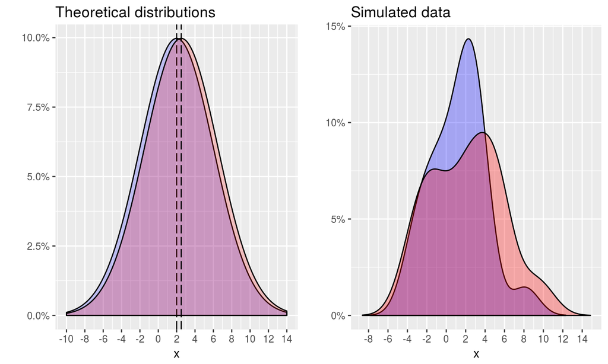

## Models

- **Full model: distinguish between X and Y**

x and y come from different distributions (different means)

Parameter space: \(\Theta \rightarrow \{ \mu_X, \mu_Y, \sigma \}\)

- **Nested model: no distinction between X and Y**

Assume x and y came from the same distribution

Parameter space: \(\Theta_0 \rightarrow \{ \mu, \sigma \}\) \(( \mu_X = \mu_Y )\)

**The nested model is a simplification of the full model. Assumes we can consider both means similar for simplicity**

## 4.4.2 - Perform MLE and compute ML values

*MLE = Maximum Likelihood Estimation*

We want to minimise the -log(likelihood) value for each model using the simulated data

Minimise: \(-\sum { \log { f_N\left( x_{ i } \right) } }\)

```r
mllk.normal <- function(params, data) {
  -(sum(log(dnorm(data, mean = params, sd = 4))))
}
```

## R implementation

Minimise (optimise), i.e get the parameters that minimise:

| Full model | Nested model |
| --- | --- |
| \(- \left( \sum_{ i = 1 }^{ 20 } { \log { f_X\left( x_{ i } \right) } } + \sum_{ i = 1}^{40} { \log { f_Y\left( y_{ i } \right) } } \right)\) | \(- \sum_{ i = 1 }^{ 60 } { \log { f_XY\left( xy_{ i } \right) } }\) |

```r
# Full model
x.params <- optimize(mllk.normal, interval = c(-10, 10), data = x)
y.params <- optimize(mllk.normal, interval = c(-10, 10), data = y)

# Nested model
xy.params <- optimize(mllk.normal, interval = c(-10, 10), data = xy)
```

## Compute likelihood using optimized parameters

1. Compute probability of each value according to model with ML parameters
2. Multiply all probabilities to obtain the likelihood of the parameters

```r
# Full model
full.model.l <- c(dnorm(x, mean = x.params$minimum, sd = 4),
                  dnorm(y, mean = y.params$minimum, sd = 4)) %>%
  prod

# Nested model
nested.model.l <- dnorm(xy, mean = xy.params$minimum, sd = 4) %>%
  prod
```

## 4.4.3 - Compute the LRT statistic and the p-value

Compute the quotient of likelihoods between the nested model and the full model

*This quotient will ALWAYS be* \(\le 1\)

```r
q <- nested.model.l / full.model.l
```

A statistic based on q is said to follow a \(\chi^2\) distribution if the nested model captures the same info as the full one

\(-2\log{\left( q \right)} \sim \chi^{2}_{n}\)

## P-value (LRT)

\(H_0\): The nested model is sufficient

- The p-value will give us the probability of observing a statistic more extreme than the observed
- If it is low, we reject the null hypothesis

```r
lrt.pval <- 1 - pchisq(statistic, df = 1)
lrt.pval
```

```
## [1] 0.4396809
```

## P4.4.4 P-value (T-test)

\(H_0\): The nested model is sufficient

- We can also use the student's T test
- All distributions considered have the same variance (homoscedastic)

```r
ttest.pval <- t.test(x, y,
                     var.equal = TRUE,
                     alternative = "two.sided")$p.value

ttest.pval
```

```
## [1] 0.370415
```

## Compare p-values

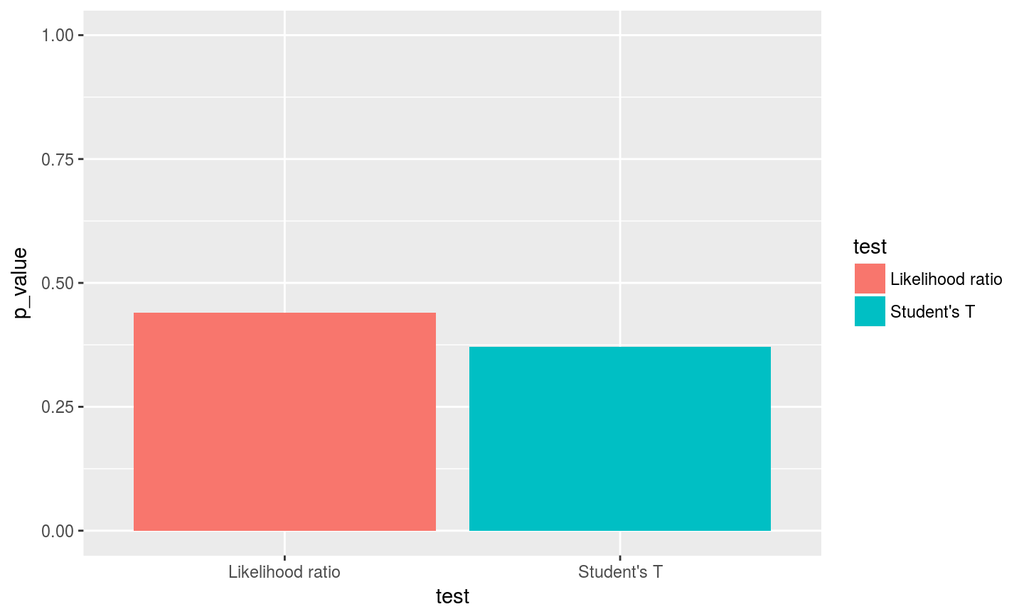